# Dias 1 e 2 - Curso R

Enggel Carmo

18/07/2021

# Curso R – Guia Prático para análise de variáveis categóricas

- Por que eu estou aprendendo isso?
  - Lembrar da Instalação do R
  - Instalação do R Studio
  - Instalação do pacote R Markdown
  - Abrir o R studio
  - Abrir o R markdown

# Dia 1- Criando um documento no R Markdown

- Será que as funções estão sendo salvas?
- Tem que dar espaço para a palavra :)
- Dar **dois espaços** no fim das linhas em branco para mostrar (ao programa) que estamos pulando uma linha (em negrito - entre asterisco)
- Para *itálico* (apenas um asteriscos)
- O R<sup>2</sup> está sobrescrito (entre circunflexo)
- O teste<sub>12</sub> está subescrito (entre til)
- Coisas com cara de código fica `shapiro.wilk` (entre acento grave)

> Link clicável abaixo

[Meu linkedin:](https://www.linkedin.com/in/enggel-carmo/)

> Adicionar imagem

[figure not shown]

### Criando referências

De acordo com Crawley 2012 [^1].

## Parte 1.

### Criar documento `RMarkdown`

### Salvar documento `Dados_CursoR.txt` na pasta para o curso

### Salvar documento **Untitled** na pasta do curso

### Salvar documento `.docx` > Mostrar documento salvo

# Dia 2 - Importar dados - Distribuição Normal

## Parte 2. Instalar pacotes

### Instalar pacotes que serão necessários para o curso

```r
library (MASS)
library (car)
library(multcompView)#TukeyHSD
library(dplyr)
library(rstatix)
library(emmeans)
library(ggplot2)
library(gplots)
```

### Importar dados `Dados_CursoR.txt`

> Os formatos mais comuns para importar dados da sua máquina são .csv ou .txt
- Lembrar que .csv deve especificar que as colunas estão separadas por ;
- Anotações dentro e fora do *{r}*

```r
dados<-read.table("Dados_CursoR.txt",h=T) #comentários > h=T quer dizer que existe um cabeçalho
dados
```

| Dieta | rep | ovos | larvas | survive | censor | total |
| --- | --- | --- | --- | --- | --- | --- |
| pulgao | cr1 | 94 | 76 | 30 | 0 | 1 |
| pulgao | cr2 | 73 | 50 | 30 | 0 | 1 |
| pulgao | cr3 | 68 | 58 | 20 | 1 | 1 |
| pulgao | cr4 | 96 | 72 | 30 | 0 | 1 |
| pulgao | cr5 | 67 | 40 | 22 | 1 | 1 |
| pulgao | cr7 | 80 | 46 | 20 | 1 | 1 |
| pulgao | cr8 | 54 | 40 | 30 | 0 | 1 |
| pulgao | cr9 | 94 | 77 | 15 | 1 | 1 |
| pulgao | cr10 | 72 | 46 | 10 | 1 | 1 |
| pulgao | cr11 | 88 | 67 | 22 | 1 | 1 |

[output cut: 35 more lines]

```r
attach(dados) #direciona que os dados utilizados será do arquivo que estamos utilizando no momento fixando na análise
summary(dados)
```

```
##     Dieta               rep                 ovos           larvas
##  Length:45          Length:45          Min.   :12.00   Min.   : 0.00
##  Class :character   Class :character   1st Qu.:29.00   1st Qu.: 3.00
##  Mode  :character   Mode  :character   Median :67.00   Median :24.00
##                                        Mean   :57.67   Mean   :28.71
##                                        3rd Qu.:80.00   3rd Qu.:46.00
##                                        Max.   :98.00   Max.   :86.00
##     survive          censor           total
##  Min.   : 6.00   Min.   :0.0000   Min.   :1
##  1st Qu.:18.00   1st Qu.:0.0000   1st Qu.:1
##  Median :25.00   Median :1.0000   Median :1
##  Mean   :23.44   Mean   :0.5556   Mean   :1
##  3rd Qu.:30.00   3rd Qu.:1.0000   3rd Qu.:1
##  Max.   :30.00   Max.   :1.0000   Max.   :1
```

```r
nrow(dados[which(dados$Dieta=="pulgao"),]) #tamanho do nível específico
```

```
## [1] 15
```

### Representação da variável **ovos**

Avaliaremos os dados de oviposição e sobrevivência da espécie *Eriopis connexa* em relação as **dietas** consumidas/ofertadas, logo são **variáveis categóricas**.

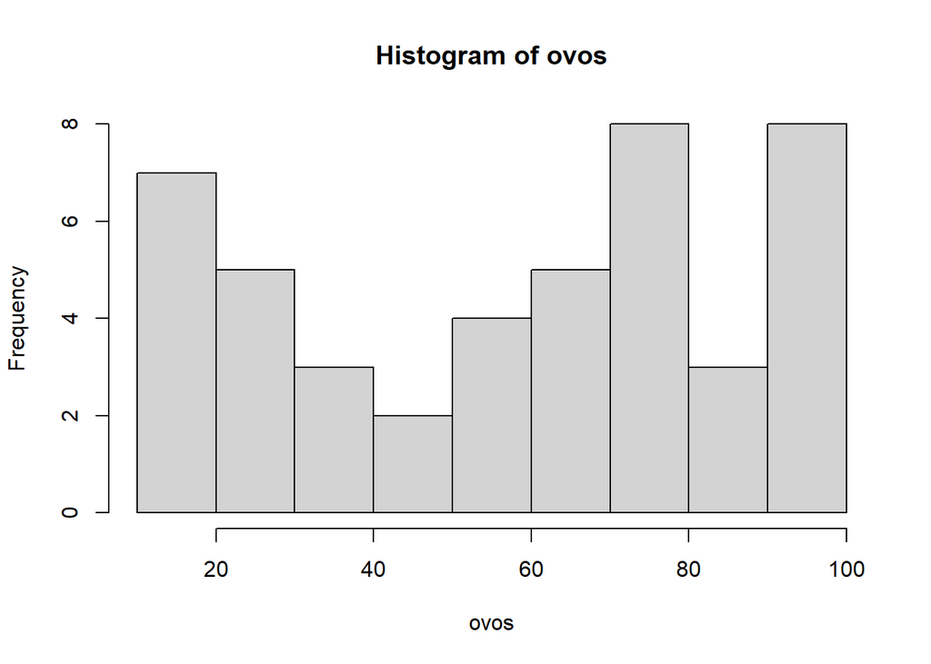

```r
hist(ovos)
```

### Representação gráfica dos quantiles

Pode auxiliar na escolha do modelo que a distribuição dos seus dados melhor se encaixa.

```
## [1] 32 42
```

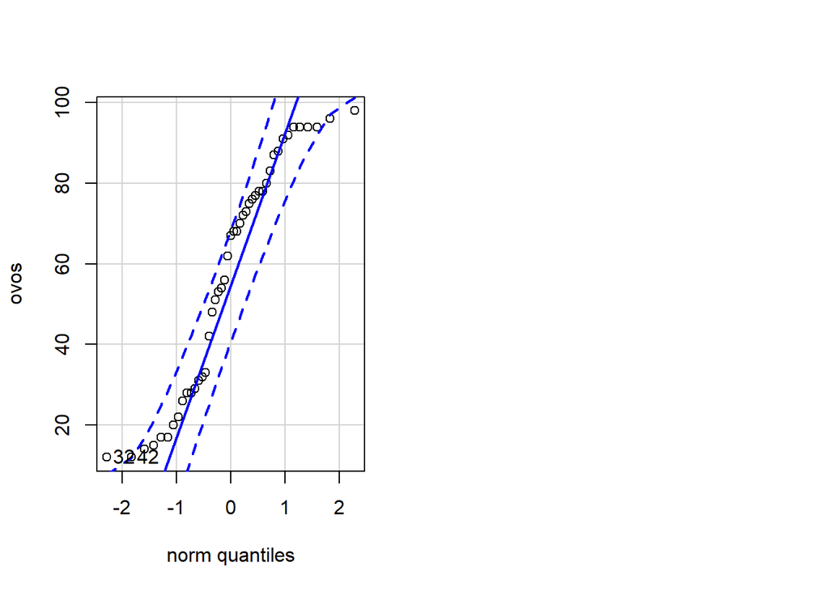

[figure not shown]

```r
par(mfrow=c(1,2)) # plot de dois gráficos na mesma folha
qqp(ovos, "norm") #quantile quantile plot da distribuição normal
```

## Parte 3. Análise para dados com distribuição Normal ou Gaussiana

### Vamos testar a distribuição para a variável **ovos**

- Distribuição Normal ou Gaussiana
  - Concentração de valores em torno de um valor central;
  - Simetria em torno do valor central;
  - Frequência pequena de valores muito extremos.

  A distribuição normal possui dois parâmetros, a média (μ), ou seja onde está centralizada e a variância (σ2>0) que descreve o seu grau de dispersão. Ou ainda o desvio padrão (σ). Cabe salientar que como qualquer outro modelo, dependendo dos parâmetros, teremos diferentes distribuições normais.

Aceitar  
H<sub>0</sub>: consistem em dizer que há normalidade nos dados - p > 0.05

H<sub>1</sub>: que não há - p < 0.05

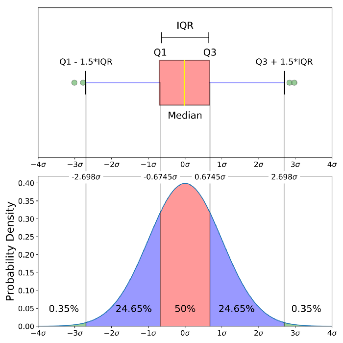

```r
shapiro.test(ovos)
```

```
##
##  Shapiro-Wilk normality test
##
## data:  ovos
## W = 0.90943, p-value = 0.001888
```

### Vamos testar a homocedasticidade para **ovos**

Homocedasticidade é o termo para designar variância constante dos erros experimentais. *Cada nível tem sua variação em torno da média, se estes apresentam grande variação, mostra que os dados não são **homogêneos**.*

Quando *p-valor* for **menor** que o nível de significância escolhido para o teste (em geral, convencionado em 0,05), rejeita-se a H<sub>0</sub> e aceitamos hipótese alternativa, assumindo a **desigualdade das variâncias**. Caso ele seja **maior** que o nível de significância, concluímos que **as variâncias são constantes ou homogêneas**.

```r
bartlett.test(ovos ~ Dieta, data = dados)
```

```
##
##  Bartlett test of homogeneity of variances
##
## data:  ovos by Dieta
## Bartlett's K-squared = 7.5519, df = 2, p-value = 0.02291
```

### Boxplot

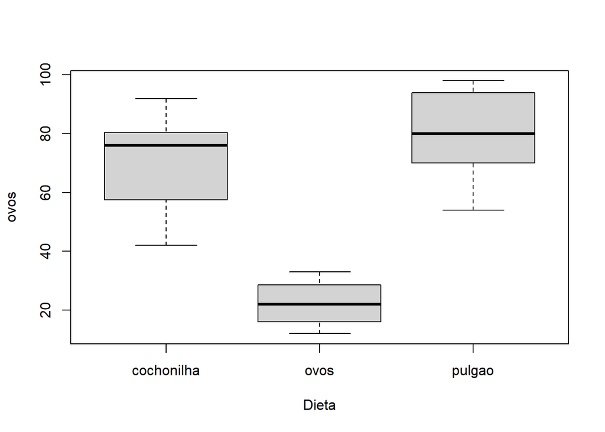

```r
boxplot(ovos~Dieta)
```

### *ANOVA*

```r
modelo1<-aov(ovos~Dieta)
anova(modelo1,test="F")
```

|  | Df | Sum Sq | Mean Sq | F value | Pr(>F) |
| --- | --- | --- | --- | --- | --- |
| Dieta | 2 | 28704.4 | 14352.2000 | 80.22684 | 4.522679e-15 |
| Residuals | 42 | 7513.6 | 178.8952 | NA | NA |

```r
Tukey<-TukeyHSD(x=modelo1,'Dieta', conf.level = 0.95)
Tukey
```

```
##   Tukey multiple comparisons of means
##     95% family-wise confidence level
##
## Fit: aov(formula = ovos ~ Dieta)
##
## $Dieta
##                    diff        lwr       upr     p adj
## ovos-cochonilha   -48.0 -59.865459 -36.13454 0.0000000
## pulgao-cochonilha   9.8  -2.065459  21.66546 0.1230937
## pulgao-ovos        57.8  45.934541  69.66546 0.0000000
```

> Extra: Shapiro-Wilk de cada nível dentro do grupo

```r
library(RVAideMemoire)
byf.shapiro(ovos~Dieta, data=dados)
```

```
##
##  Shapiro-Wilk normality tests
##
## data:  ovos by Dieta
##
##                 W p-value
## cochonilha 0.9375 0.35216
## ovos       0.9083 0.12737
## pulgao     0.8939 0.07693 .
## ---
## Signif. codes:  0 '***' 0.001 '**' 0.01 '*' 0.05 '.' 0.1 ' ' 1
```

## Análise descritiva

### Médias e erros

```r
medias<-tapply(ovos, Dieta, mean)
medias
```

```
## cochonilha       ovos     pulgao
##       70.4       22.4       80.2
```

```r
erro<-tapply(ovos, Dieta, sd)/sqrt(tapply(ovos, Dieta, length))
erro
```

```
## cochonilha       ovos     pulgao
##   4.128646   1.956187   3.860915
```

### Representação em Barplot

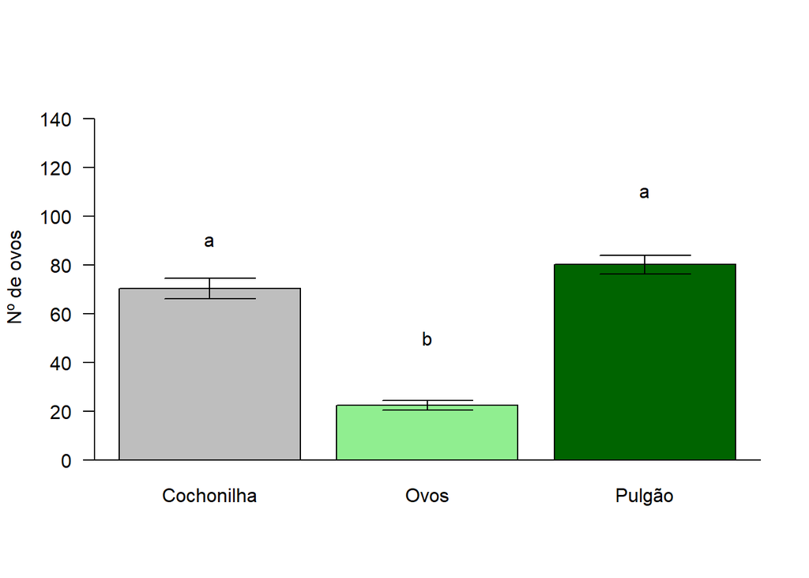

```r
barplot2(medias,
 plot.ci=T,
 ci.u=medias+erro,
 ci.l=medias-erro,
 ylab="Nº de ovos",
 ylim=c(0,150),
 las=1,
 names.arg = c("Cochonilha","Ovos", "Pulgão"),
 col=c("gray","lightgreen", "darkgreen"))
 text(0.7,90,"a")
 text(1.9,50,"b")
 text(3.1,110,"a")
abline(h=0)
```

Livro R markdown [^2]. [Livro:](https://bookdown.org/yihui/bookdown/)

**Lembrar de fazer o `detach` para desafixar a tabela do programa.**

```r
detach(dados)
```

**Risco de “chamar” variável de outra tabela por ter nomes idênticos.**

**Salvar documento `.docx` > Mostrar documento salvo**

#### Exercício: Façam o mesmo script para `larvas`.

> Quem souber transformar para Box-Cox, log ou sqrt fique à vontade também ou ver se a distribuição se encaixa melhor para Gamma.

Vem aí:

# Dia 3 - E quando nossos dados não apresentam distribuição normal?

- GLM - Distribuição Poisson
- GLM - Distribuição Binomial Negativa.
- Análise de contraste.
[^1]: Crawley, M. J. (2012). The R book. John Wiley & Sons.
[^2]: Xie, Y. (2016). Bookdown: authoring books and technical documents with R markdown. CRC Press.